# Risk Factor Analysis

## Outcome Variable

**Outcome Variable:** pers_wasted624

## Predictor Variables

**Intervention Variable:** ever_wasted06

**Adjustment Set:**

- sex
- arm
- brthmon
- vagbrth
- single
- W_mage
- W_mhtcm
- W_mwtkg
- W_mbmi
- W_meducyrs
- W_feducyrs
- W_parity
- delta_brthmon
- delta_vagbrth
- delta_single
- delta_W_mage
- delta_W_mhtcm
- delta_W_mwtkg
- delta_W_mbmi
- delta_W_meducyrs
- delta_W_feducyrs
- delta_W_parity

## Stratifying Variables

The analysis was stratified on these variable(s):

- studyid
- country

## Data Summary

| studyid | country | ever_wasted06 | pers_wasted624 | n_cell | n |
| --- | --- | --- | --- | --- | --- |
| CMC-V-BCS-2002 | INDIA | 0 | 0 | 175 | 370 |
| CMC-V-BCS-2002 | INDIA | 0 | 1 | 3 | 370 |
| CMC-V-BCS-2002 | INDIA | 1 | 0 | 167 | 370 |
| CMC-V-BCS-2002 | INDIA | 1 | 1 | 25 | 370 |
| CMIN | BANGLADESH | 0 | 0 | 196 | 252 |
| CMIN | BANGLADESH | 0 | 1 | 11 | 252 |
| CMIN | BANGLADESH | 1 | 0 | 31 | 252 |
| CMIN | BANGLADESH | 1 | 1 | 14 | 252 |
| COHORTS | GUATEMALA | 0 | 0 | 786 | 1017 |
| COHORTS | GUATEMALA | 0 | 1 | 25 | 1017 |
| COHORTS | GUATEMALA | 1 | 0 | 190 | 1017 |
| COHORTS | GUATEMALA | 1 | 1 | 16 | 1017 |
| COHORTS | INDIA | 0 | 0 | 4756 | 6892 |
| COHORTS | INDIA | 0 | 1 | 113 | 6892 |
| COHORTS | INDIA | 1 | 0 | 1366 | 6892 |
| COHORTS | INDIA | 1 | 1 | 657 | 6892 |
| COHORTS | PHILIPPINES | 0 | 0 | 2013 | 2808 |
| COHORTS | PHILIPPINES | 0 | 1 | 98 | 2808 |
| COHORTS | PHILIPPINES | 1 | 0 | 569 | 2808 |
| COHORTS | PHILIPPINES | 1 | 1 | 128 | 2808 |
| CONTENT | PERU | 0 | 0 | 211 | 215 |
| CONTENT | PERU | 0 | 1 | 0 | 215 |
| CONTENT | PERU | 1 | 0 | 4 | 215 |
| CONTENT | PERU | 1 | 1 | 0 | 215 |
| EE | PAKISTAN | 0 | 0 | 234 | 374 |
| EE | PAKISTAN | 0 | 1 | 12 | 374 |
| EE | PAKISTAN | 1 | 0 | 91 | 374 |
| EE | PAKISTAN | 1 | 1 | 37 | 374 |
| GMS-Nepal | NEPAL | 0 | 0 | 319 | 590 |
| GMS-Nepal | NEPAL | 0 | 1 | 34 | 590 |

[output cut: 90 more lines]

The following strata were considered:

- studyid: CMC-V-BCS-2002, country: INDIA
- studyid: CMIN, country: BANGLADESH
- studyid: COHORTS, country: GUATEMALA
- studyid: COHORTS, country: INDIA
- studyid: COHORTS, country: PHILIPPINES
- studyid: CONTENT, country: PERU
- studyid: EE, country: PAKISTAN
- studyid: GMS-Nepal, country: NEPAL
- studyid: Guatemala BSC, country: GUATEMALA
- studyid: IRC, country: INDIA
- studyid: JiVitA-3, country: BANGLADESH
- studyid: JiVitA-4, country: BANGLADESH
- studyid: Keneba, country: GAMBIA
- studyid: LCNI-5, country: MALAWI
- studyid: MAL-ED, country: BANGLADESH
- studyid: MAL-ED, country: BRAZIL
- studyid: MAL-ED, country: INDIA
- studyid: MAL-ED, country: NEPAL
- studyid: MAL-ED, country: PERU
- studyid: MAL-ED, country: SOUTH AFRICA
- studyid: MAL-ED, country: TANZANIA, UNITED REPUBLIC OF
- studyid: NIH-Birth, country: BANGLADESH
- studyid: NIH-Crypto, country: BANGLADESH
- studyid: PROBIT, country: BELARUS
- studyid: PROVIDE, country: BANGLADESH
- studyid: ResPak, country: PAKISTAN
- studyid: SAS-CompFeed, country: INDIA
- studyid: SAS-FoodSuppl, country: INDIA
- studyid: TanzaniaChild2, country: TANZANIA, UNITED REPUBLIC OF
- studyid: ZVITAMBO, country: ZIMBABWE

### Dropped Strata

Some strata were dropped due to rare outcomes:

- studyid: CMC-V-BCS-2002, country: INDIA
- studyid: CONTENT, country: PERU
- studyid: Guatemala BSC, country: GUATEMALA
- studyid: MAL-ED, country: BANGLADESH
- studyid: MAL-ED, country: BRAZIL
- studyid: MAL-ED, country: NEPAL
- studyid: MAL-ED, country: PERU
- studyid: MAL-ED, country: SOUTH AFRICA
- studyid: MAL-ED, country: TANZANIA, UNITED REPUBLIC OF
- studyid: PROBIT, country: BELARUS

## Methods Detail

We’re interested in the causal parameters $E[Y_a]$ for all values of $a \in \mathcal{A}$. These parameters represent the mean outcome if, possibly contrary to fact, we intervened to set all units to have $A=a$. Under the randomization and positivity assumptions, these are identified by the statistical parameters $\psi_a=E_W[E_{Y|A,W}(Y|A=a,W)]$. In addition, we’re interested in the mean of $Y$, $E[Y]$ under no intervention (the observed mean). We will estimate these parameters by using SuperLearner to fit the relevant likelihood factors – $E_{Y|A,W}(Y|A=a,W)$ and $p(A=a|W)$, and then updating our likelihood fit using a joint TMLE.

For unadjusted analyses ($W=\{\}$), initial likelihoods were estimated using Lrnr_glm to estimate the simple $E(Y|A)$ and Lrnr_mean to estimate $p(A)$. For adjusted analyses, a small library containing Lrnr_glmnet, Lrnr_xgboost, and Lrnr_mean was used.

Having estimated these parameters, we will then use the delta method to estimate relative risks and attributable risks relative to a prespecified baseline level of $A$.

# Results Detail

## Results Plots

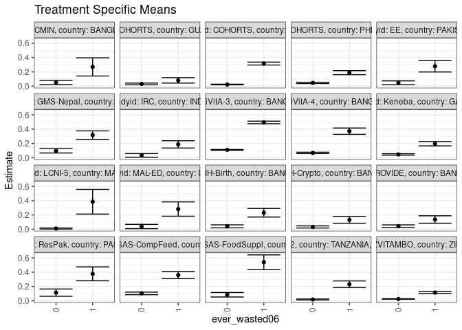

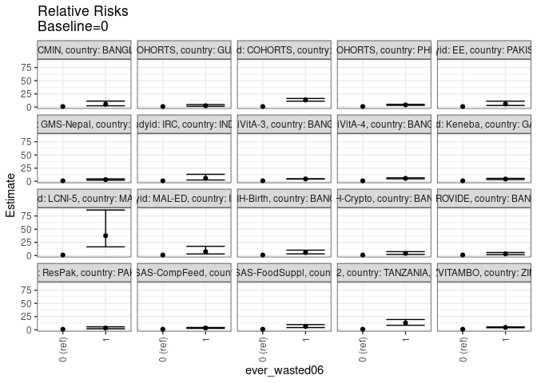

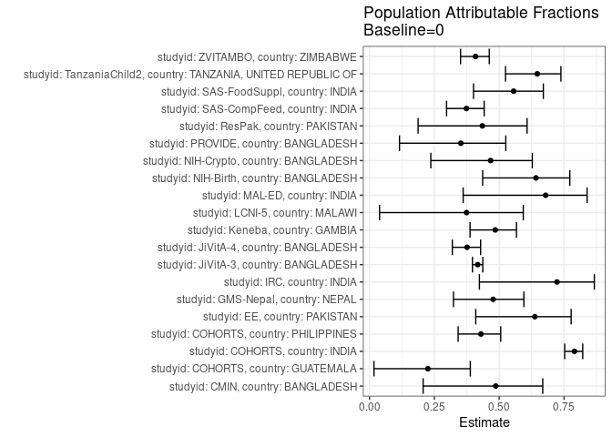

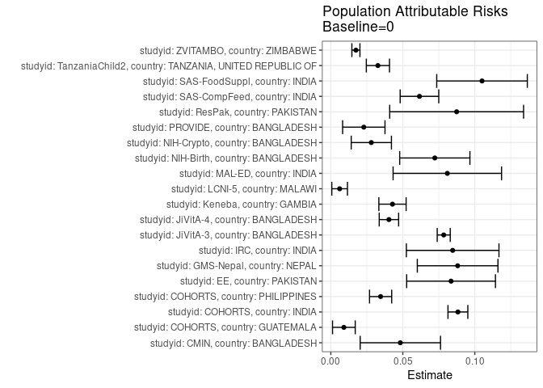

## Results Table

### Parameter: TSM

| studyid | country | intervention_level | baseline_level | estimate | ci_lower | ci_upper |
| --- | --- | --- | --- | --- | --- | --- |
| CMIN | BANGLADESH | 0 | NA | 0.0509126 | 0.0210760 | 0.0807492 |
| CMIN | BANGLADESH | 1 | NA | 0.2695627 | 0.1421663 | 0.3969590 |
| COHORTS | GUATEMALA | 0 | NA | 0.0312476 | 0.0192494 | 0.0432459 |
| COHORTS | GUATEMALA | 1 | NA | 0.0814665 | 0.0435185 | 0.1194144 |
| COHORTS | INDIA | 0 | NA | 0.0234452 | 0.0192105 | 0.0276800 |
| COHORTS | INDIA | 1 | NA | 0.3163221 | 0.2962741 | 0.3363700 |
| COHORTS | PHILIPPINES | 0 | NA | 0.0459032 | 0.0369575 | 0.0548488 |
| COHORTS | PHILIPPINES | 1 | NA | 0.1891577 | 0.1607772 | 0.2175382 |
| EE | PAKISTAN | 0 | NA | 0.0474922 | 0.0205530 | 0.0744314 |
| EE | PAKISTAN | 1 | NA | 0.2794592 | 0.1988988 | 0.3600197 |
| GMS-Nepal | NEPAL | 0 | NA | 0.0966490 | 0.0659361 | 0.1273619 |
| GMS-Nepal | NEPAL | 1 | NA | 0.3162525 | 0.2571087 | 0.3753963 |
| IRC | INDIA | 0 | NA | 0.0324324 | 0.0068747 | 0.0579902 |
| IRC | INDIA | 1 | NA | 0.1866667 | 0.1356920 | 0.2376414 |
| JiVitA-3 | BANGLADESH | 0 | NA | 0.1095717 | 0.1040984 | 0.1150449 |
| JiVitA-3 | BANGLADESH | 1 | NA | 0.4934566 | 0.4753634 | 0.5115498 |
| JiVitA-4 | BANGLADESH | 0 | NA | 0.0669129 | 0.0577166 | 0.0761091 |
| JiVitA-4 | BANGLADESH | 1 | NA | 0.3709266 | 0.3264938 | 0.4153594 |
| Keneba | GAMBIA | 0 | NA | 0.0455060 | 0.0354190 | 0.0555931 |
| Keneba | GAMBIA | 1 | NA | 0.1959311 | 0.1653568 | 0.2265053 |
| LCNI-5 | MALAWI | 0 | NA | 0.0102041 | 0.0031022 | 0.0173060 |
| LCNI-5 | MALAWI | 1 | NA | 0.3846154 | 0.2119598 | 0.5572710 |
| MAL-ED | INDIA | 0 | NA | 0.0382166 | 0.0081635 | 0.0682696 |
| MAL-ED | INDIA | 1 | NA | 0.2820513 | 0.1819735 | 0.3821290 |
| NIH-Birth | BANGLADESH | 0 | NA | 0.0403137 | 0.0192759 | 0.0613515 |
| NIH-Birth | BANGLADESH | 1 | NA | 0.2307434 | 0.1709561 | 0.2905307 |
| NIH-Crypto | BANGLADESH | 0 | NA | 0.0321388 | 0.0172524 | 0.0470253 |
| NIH-Crypto | BANGLADESH | 1 | NA | 0.1319981 | 0.0836727 | 0.1803235 |
| PROVIDE | BANGLADESH | 0 | NA | 0.0421335 | 0.0237980 | 0.0604690 |
| PROVIDE | BANGLADESH | 1 | NA | 0.1357643 | 0.0833653 | 0.1881632 |
| ResPak | PAKISTAN | 0 | NA | 0.1134488 | 0.0624098 | 0.1644878 |
| ResPak | PAKISTAN | 1 | NA | 0.3767796 | 0.2795335 | 0.4740258 |
| SAS-CompFeed | INDIA | 0 | NA | 0.1031635 | 0.0852746 | 0.1210524 |
| SAS-CompFeed | INDIA | 1 | NA | 0.3596259 | 0.3100674 | 0.4091843 |
| SAS-FoodSuppl | INDIA | 0 | NA | 0.0840180 | 0.0525166 | 0.1155195 |
| SAS-FoodSuppl | INDIA | 1 | NA | 0.5391283 | 0.4363753 | 0.6418812 |
| TanzaniaChild2 | TANZANIA, UNITED REPUBLIC OF | 0 | NA | 0.0178424 | 0.0114652 | 0.0242197 |
| TanzaniaChild2 | TANZANIA, UNITED REPUBLIC OF | 1 | NA | 0.2305787 | 0.1838134 | 0.2773440 |
| ZVITAMBO | ZIMBABWE | 0 | NA | 0.0251678 | 0.0218772 | 0.0284584 |
| ZVITAMBO | ZIMBABWE | 1 | NA | 0.1148720 | 0.1009250 | 0.1288189 |

### Parameter: E(Y)

| studyid | country | intervention_level | baseline_level | estimate | ci_lower | ci_upper |
| --- | --- | --- | --- | --- | --- | --- |
| CMIN | BANGLADESH | NA | NA | 0.0992063 | 0.0622241 | 0.1361886 |
| COHORTS | GUATEMALA | NA | NA | 0.0403147 | 0.0282199 | 0.0524094 |
| COHORTS | INDIA | NA | NA | 0.1117237 | 0.1042858 | 0.1191617 |
| COHORTS | PHILIPPINES | NA | NA | 0.0804843 | 0.0704205 | 0.0905481 |
| EE | PAKISTAN | NA | NA | 0.1310160 | 0.0967738 | 0.1652583 |
| GMS-Nepal | NEPAL | NA | NA | 0.1847458 | 0.1534039 | 0.2160876 |
| IRC | INDIA | NA | NA | 0.1170732 | 0.0859146 | 0.1482317 |
| JiVitA-3 | BANGLADESH | NA | NA | 0.1880070 | 0.1814627 | 0.1945512 |
| JiVitA-4 | BANGLADESH | NA | NA | 0.1072724 | 0.0967392 | 0.1178055 |
| Keneba | GAMBIA | NA | NA | 0.0883377 | 0.0767324 | 0.0999430 |
| LCNI-5 | MALAWI | NA | NA | 0.0163112 | 0.0075116 | 0.0251108 |
| MAL-ED | INDIA | NA | NA | 0.1191489 | 0.0776405 | 0.1606574 |
| NIH-Birth | BANGLADESH | NA | NA | 0.1125461 | 0.0859151 | 0.1391771 |
| NIH-Crypto | BANGLADESH | NA | NA | 0.0602740 | 0.0429977 | 0.0775502 |
| PROVIDE | BANGLADESH | NA | NA | 0.0650407 | 0.0455353 | 0.0845460 |
| ResPak | PAKISTAN | NA | NA | 0.2008547 | 0.1494120 | 0.2522974 |
| SAS-CompFeed | INDIA | NA | NA | 0.1647399 | 0.1451050 | 0.1843747 |
| SAS-FoodSuppl | INDIA | NA | NA | 0.1890547 | 0.1507312 | 0.2273783 |
| TanzaniaChild2 | TANZANIA, UNITED REPUBLIC OF | NA | NA | 0.0505451 | 0.0409848 | 0.0601054 |
| ZVITAMBO | ZIMBABWE | NA | NA | 0.0425869 | 0.0387663 | 0.0464075 |

### Parameter: RR

| studyid | country | intervention_level | baseline_level | estimate | ci_lower | ci_upper |
| --- | --- | --- | --- | --- | --- | --- |
| CMIN | BANGLADESH | 0 | 0 | 1.000000 | 1.000000 | 1.000000 |
| CMIN | BANGLADESH | 1 | 0 | 5.294615 | 2.488412 | 11.265399 |
| COHORTS | GUATEMALA | 0 | 0 | 1.000000 | 1.000000 | 1.000000 |
| COHORTS | GUATEMALA | 1 | 0 | 2.607123 | 1.427473 | 4.761625 |
| COHORTS | INDIA | 0 | 0 | 1.000000 | 1.000000 | 1.000000 |
| COHORTS | INDIA | 1 | 0 | 13.491952 | 11.147500 | 16.329470 |
| COHORTS | PHILIPPINES | 0 | 0 | 1.000000 | 1.000000 | 1.000000 |
| COHORTS | PHILIPPINES | 1 | 0 | 4.120799 | 3.227015 | 5.262133 |
| EE | PAKISTAN | 0 | 0 | 1.000000 | 1.000000 | 1.000000 |
| EE | PAKISTAN | 1 | 0 | 5.884317 | 3.112857 | 11.123280 |
| GMS-Nepal | NEPAL | 0 | 0 | 1.000000 | 1.000000 | 1.000000 |
| GMS-Nepal | NEPAL | 1 | 0 | 3.272176 | 2.265551 | 4.726064 |
| IRC | INDIA | 0 | 0 | 1.000000 | 1.000000 | 1.000000 |
| IRC | INDIA | 1 | 0 | 5.755556 | 2.499673 | 13.252299 |
| JiVitA-3 | BANGLADESH | 0 | 0 | 1.000000 | 1.000000 | 1.000000 |
| JiVitA-3 | BANGLADESH | 1 | 0 | 4.503505 | 4.244104 | 4.778759 |
| JiVitA-4 | BANGLADESH | 0 | 0 | 1.000000 | 1.000000 | 1.000000 |
| JiVitA-4 | BANGLADESH | 1 | 0 | 5.543426 | 4.635028 | 6.629857 |
| Keneba | GAMBIA | 0 | 0 | 1.000000 | 1.000000 | 1.000000 |
| Keneba | GAMBIA | 1 | 0 | 4.305605 | 3.283521 | 5.645840 |
| LCNI-5 | MALAWI | 0 | 0 | 1.000000 | 1.000000 | 1.000000 |
| LCNI-5 | MALAWI | 1 | 0 | 37.692308 | 16.465322 | 86.284983 |
| MAL-ED | INDIA | 0 | 0 | 1.000000 | 1.000000 | 1.000000 |
| MAL-ED | INDIA | 1 | 0 | 7.380342 | 3.114563 | 17.488630 |
| NIH-Birth | BANGLADESH | 0 | 0 | 1.000000 | 1.000000 | 1.000000 |
| NIH-Birth | BANGLADESH | 1 | 0 | 5.723699 | 3.195763 | 10.251301 |
| NIH-Crypto | BANGLADESH | 0 | 0 | 1.000000 | 1.000000 | 1.000000 |
| NIH-Crypto | BANGLADESH | 1 | 0 | 4.107123 | 2.277785 | 7.405641 |
| PROVIDE | BANGLADESH | 0 | 0 | 1.000000 | 1.000000 | 1.000000 |
| PROVIDE | BANGLADESH | 1 | 0 | 3.222242 | 1.801197 | 5.764414 |
| ResPak | PAKISTAN | 0 | 0 | 1.000000 | 1.000000 | 1.000000 |
| ResPak | PAKISTAN | 1 | 0 | 3.321142 | 1.963869 | 5.616455 |
| SAS-CompFeed | INDIA | 0 | 0 | 1.000000 | 1.000000 | 1.000000 |
| SAS-CompFeed | INDIA | 1 | 0 | 3.485980 | 2.790147 | 4.355347 |
| SAS-FoodSuppl | INDIA | 0 | 0 | 1.000000 | 1.000000 | 1.000000 |
| SAS-FoodSuppl | INDIA | 1 | 0 | 6.416815 | 4.202810 | 9.797140 |
| TanzaniaChild2 | TANZANIA, UNITED REPUBLIC OF | 0 | 0 | 1.000000 | 1.000000 | 1.000000 |
| TanzaniaChild2 | TANZANIA, UNITED REPUBLIC OF | 1 | 0 | 12.923047 | 8.565947 | 19.496402 |
| ZVITAMBO | ZIMBABWE | 0 | 0 | 1.000000 | 1.000000 | 1.000000 |
| ZVITAMBO | ZIMBABWE | 1 | 0 | 4.564248 | 3.819518 | 5.454186 |

### Parameter: PAR

| studyid | country | intervention_level | baseline_level | estimate | ci_lower | ci_upper |
| --- | --- | --- | --- | --- | --- | --- |
| CMIN | BANGLADESH | 0 | NA | 0.0482937 | 0.0203832 | 0.0762043 |
| COHORTS | GUATEMALA | 0 | NA | 0.0090670 | 0.0011837 | 0.0169503 |
| COHORTS | INDIA | 0 | NA | 0.0882785 | 0.0813807 | 0.0951763 |
| COHORTS | PHILIPPINES | 0 | NA | 0.0345812 | 0.0268836 | 0.0422788 |
| EE | PAKISTAN | 0 | NA | 0.0835238 | 0.0526829 | 0.1143648 |
| GMS-Nepal | NEPAL | 0 | NA | 0.0880968 | 0.0600833 | 0.1161103 |
| IRC | INDIA | 0 | NA | 0.0846407 | 0.0524758 | 0.1168057 |
| JiVitA-3 | BANGLADESH | 0 | NA | 0.0784353 | 0.0739066 | 0.0829640 |
| JiVitA-4 | BANGLADESH | 0 | NA | 0.0403595 | 0.0336237 | 0.0470953 |
| Keneba | GAMBIA | 0 | NA | 0.0428316 | 0.0333613 | 0.0523020 |
| LCNI-5 | MALAWI | 0 | NA | 0.0061071 | 0.0006741 | 0.0115401 |
| MAL-ED | INDIA | 0 | NA | 0.0809324 | 0.0432584 | 0.1186063 |
| NIH-Birth | BANGLADESH | 0 | NA | 0.0722324 | 0.0478426 | 0.0966222 |
| NIH-Crypto | BANGLADESH | 0 | NA | 0.0281352 | 0.0141673 | 0.0421030 |
| PROVIDE | BANGLADESH | 0 | NA | 0.0229072 | 0.0081873 | 0.0376271 |
| ResPak | PAKISTAN | 0 | NA | 0.0874059 | 0.0409030 | 0.1339087 |
| SAS-CompFeed | INDIA | 0 | NA | 0.0615764 | 0.0481720 | 0.0749808 |
| SAS-FoodSuppl | INDIA | 0 | NA | 0.1050367 | 0.0735679 | 0.1365054 |
| TanzaniaChild2 | TANZANIA, UNITED REPUBLIC OF | 0 | NA | 0.0327027 | 0.0246558 | 0.0407495 |
| ZVITAMBO | ZIMBABWE | 0 | NA | 0.0174191 | 0.0146182 | 0.0202200 |

### Parameter: PAF

| studyid | country | intervention_level | baseline_level | estimate | ci_lower | ci_upper |
| --- | --- | --- | --- | --- | --- | --- |
| CMIN | BANGLADESH | 0 | NA | 0.4868009 | 0.2067856 | 0.6679671 |
| COHORTS | GUATEMALA | 0 | NA | 0.2249059 | 0.0171865 | 0.3887234 |
| COHORTS | INDIA | 0 | NA | 0.7901499 | 0.7524824 | 0.8220851 |
| COHORTS | PHILIPPINES | 0 | NA | 0.4296634 | 0.3416901 | 0.5058803 |
| EE | PAKISTAN | 0 | NA | 0.6375084 | 0.4096573 | 0.7774172 |
| GMS-Nepal | NEPAL | 0 | NA | 0.4768542 | 0.3237837 | 0.5952751 |
| IRC | INDIA | 0 | NA | 0.7229730 | 0.4236989 | 0.8668336 |
| JiVitA-3 | BANGLADESH | 0 | NA | 0.4171935 | 0.3969206 | 0.4367849 |
| JiVitA-4 | BANGLADESH | 0 | NA | 0.3762339 | 0.3193668 | 0.4283498 |
| Keneba | GAMBIA | 0 | NA | 0.4848626 | 0.3876406 | 0.5666491 |
| LCNI-5 | MALAWI | 0 | NA | 0.3744113 | 0.0387300 | 0.5928707 |
| MAL-ED | INDIA | 0 | NA | 0.6792539 | 0.3611538 | 0.8389627 |
| NIH-Birth | BANGLADESH | 0 | NA | 0.6418030 | 0.4363227 | 0.7723785 |
| NIH-Crypto | BANGLADESH | 0 | NA | 0.4667878 | 0.2364302 | 0.6276499 |
| PROVIDE | BANGLADESH | 0 | NA | 0.3521978 | 0.1156754 | 0.5254596 |
| ResPak | PAKISTAN | 0 | NA | 0.4351697 | 0.1872289 | 0.6074747 |
| SAS-CompFeed | INDIA | 0 | NA | 0.3737796 | 0.2971325 | 0.4420684 |
| SAS-FoodSuppl | INDIA | 0 | NA | 0.5555887 | 0.4010328 | 0.6702634 |
| TanzaniaChild2 | TANZANIA, UNITED REPUBLIC OF | 0 | NA | 0.6469995 | 0.5243903 | 0.7380009 |
| ZVITAMBO | ZIMBABWE | 0 | NA | 0.4090255 | 0.3511081 | 0.4617734 |